# STAT 413/613 Week 5: Getting Web Data Through APIs

Richard Ressler

2020-02-21

# 1 Learning Outcomes

- Use R tools for Interacting with Application Programming Interfaces (APIs) to obtain data from web and other sources

## 1.1 References

- [Chapter 1, 2, and 3 from An Introduction to APIs](https://zapier.com/learn/apis/).
- [Chapter 40 from STAT 545](https://stat545.com/diy-web-data.html).
- [API Package Best Practices](https://httr.r-lib.org/articles/api-packages.html).

# 2 Data on the Web

- There are at least 4 ways people download data on the web:
  1. Click to download a csv/xls/txt file.
  2. Use a package that interacts with an API.
  3. Use an API directly.
  4. Scrape from directly from the HTML file.
- We know how to do 1.
- This lesson is about doing 2 and 3.
- Let’s load the tidyverse:

  ```r
  library(tidyverse)
  ```

# 3 R Package API Wrappers

- API: Application Programming Interface
  - A description of how you can request data from a particular software, and a description of what type of response you get after the request.
  - Usually, the data you get back are XML or JSON files.
  - API’s are an abstraction and can be implemented in many languages.
  - Think of it like a user interface for a computer program.
    - You click a button and expect the user interface to do something.
    - An API lets a program click a metaphorical “button” and expect to get something back.
  - There are lots of free and public APIs: https://github.com/public-apis/public-apis
- Many of the most popular databases/websites already have an R package someone wrote with functions to  
  “wrap the API” so you can use the familiar syntax of an R function to request data.
- If an R package exists for an API, you should use it.
- Examples:
  - tidycensus: U.S. Census data API.

    https://walkerke.github.io/tidycensus/
  - twitteR: Twitter API.

    http://geoffjentry.hexdump.org/twitteR.pdf
  - gh: GitHub API.

    https://github.com/r-lib/gh#readme
  - wbstats: World Bank data.

    https://cran.r-project.org/web/packages/wbstats/vignettes/Using_the_wbstats_package.html
  - rebird: Ebird dataset for bird sitings.

    https://cran.r-project.org/web/packages/rebird/vignettes/rebird_vignette.html
  - geonames: Dataset containing unique names for geographic locations.

    https://docs.ropensci.org/geonames/
  - rplos: The PLoS journal articles.

    https://cran.r-project.org/web/packages/rplos/vignettes/rplos_vignette.html
  - WikipediR: Wikipedia API:

    https://cran.r-project.org/web/packages/WikipediR/vignettes/WikipediR.html
- **Each package will be unique**. You have to read its documentation to know how to download data. So we won’t cover any of them.
- Example: The following will find all of the PLoS journal articles that contain the word “polyploid” in the abstract.

  ```r
  library(rplos)
  plout <- plosabstract("polyploid", limit = 1000)
  plout
  ```

# 4 Use the httr package to access APIs directly

- The goal of this section is not to provide a comprehensive lesson on HTTP and extracting data using API’s. Rather, this just points you to some resources and gives you some examples.
- Each API is different, so you always have to figure out how to interact with a new API.
- APIs should always have documentation
  - What parameters you can send,
  - How you can send them, and
  - What data you should get back based on the values of those parameters.
- E.g.: OMDB (an open-source version of IMDB) has a simple API http://www.omdbapi.com/

## 4.1 API keys

- To access an API, you usually have to obtain an API key.
- To obtain a free key from OMDB and access it in R:
  1. Sign up for a free key: https://www.omdbapi.com/apikey.aspx
  2. Open up your .Renviron file using the usethis package.

     ```r
     library(usethis)
     edit_r_environ()
     ```

  3. Add the key OMDB sent you by email to the .Renviron package. You can call it `OMDB_API_KEY`, for example. In which case you would write the following in .Renviron:

     ```
     OMDB_API_KEY = <your-private-key>
     ```

     Where “`<your-private-key>`” is the private key OMDB sent you by email.
  4. **Restart R.**
  5. You can now always access your private key by

     ```r
     movie_key <- Sys.getenv("OMDB_API_KEY")
     ```

- **Never save or display your private key in a file you could share.**
  - You are responsible for all behavior associated with your key.
  - That is why we saved it to our .Renviron and are only accessing it secretly through `Sys.getenv(key_name)`.

### 4.1.1 Another layer of security

- It is still not great your key is in a plain text environment.
- You can add a layer of security by using the keyring package: https://github.com/r-lib/keyring
  - This puts the key into your computer’s key and credential manager for storage

    ```r
    # install.packages("keyring")
    library(keyring)
    ```

    ```r
    # key_set("OMDB_API_KEY_SECURE") ## do this once to save the key
    ```

    ```r
    movie_key_2 <- key_get("OMDB_API_KEY_SECURE") ## do this each time you need the key
    ```

> A person *with password access to your computer* who knows R and the keyring package could still get to your key. But it is more secure than placing your key in a plain text file like .Renviron.
- There are more details about secure ways to access keys in R at this [vignette](https://cran.r-project.org/web/packages/httr/vignettes/secrets.html).

## 4.2 httr

- Most API’s on the web use HTTP (Hyper-Text Transfer Protocol). It’s a language for querying and obtaining data.
- We won’t learn HTTP, but we will use R’s interface for HTTP through the httr package.

  ```r
  library(httr)
  ```

- The major function we will use is `GET()` which fetches data from a URL (notice all caps).
- There are many other function in httr used to interact with API’s.
  - The six most common http verbs: `GET()`, `PATCH()`, `POST()`, `HEAD()`, `PUT()`, and `DELETE()`.
- Let’s use `GET()` to fetch the movie information on The Lighthouse.

  ```r
  mout <- GET(url = "http://www.omdbapi.com/",
              query = list(t = "The Lighthouse",
                           plot = "short",
                           r = "json",
                           apikey = movie_key_2))
  ```

- The `url` argument is the URL where all API requests should be sent.
  - This is usually spelled out in the API documentation.
  - OMDB says to send all requests to “[http://www.omdbapi.com/?apikey=[yourkey]&](http://www.omdbapi.com/?apikey=%5Byourkey%5D&)”.
  - The terms after `?` are queries, so I just used the base URL.
- The variable after `?` indicates that `apikey` is a query, so I included it in the list of queries.
- You use the `query` argument to modify the parameters of your request. It needs to be a *named list* where the names are the parameters from the API documentation.
- Other API’s use headers or body information instead of queries to modify requests. See https://httr.r-lib.org/articles/api-packages.html#first-steps
  1. URL path: the `path` argument in `GET()`.
  2. Query arguments: The `query` argument in `GET()`.
  3. HTTP headers: `add_headers()`
  4. Request body: The body argument in `GET()`.
- In the API documentation:

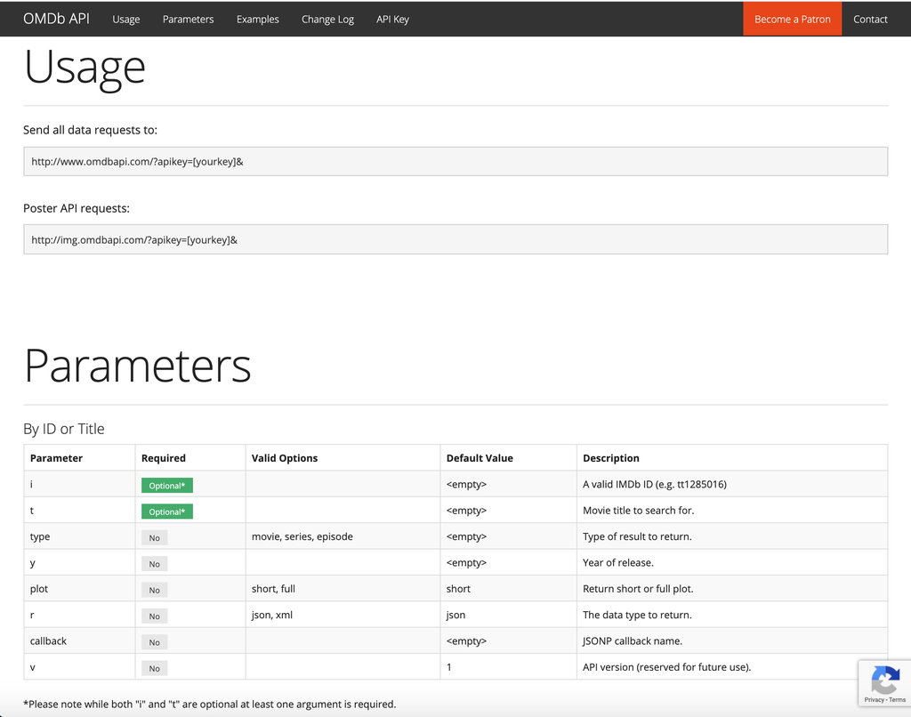

- The *status code* describes whether your request was successful.
  - List of codes: https://www.flickr.com/photos/girliemac/sets/72157628409467125
  - Use `status_code()` to get the code for our request:

    ```r
    status_code(mout)
    ```

    ```
    ## [1] 200
    ```

- *Headers* provide information on the request. Use the `headers()` function to see what headers we got in our request.

  ```r
  headers(mout)
  ```

- The *body* contains the data you are probably most interested in stored in raw form. `content()` will parse this into an R object (usually a list).

  ```r
  content(mout)
  # mout$content
  # content(mout, "raw") # to compare to mout$content
  ```

You can also see as the form of either a JSON (keys and values) or XML data structure using the `as = "text"` argument:

[output not shown]

## 4.3 Basic Authentication

- Other API’s use what’s called “Basic” authentication, where you provide a username and password. The basic syntax for this is:

  ```r
  GET("url", authenticate("username", "password"))
  ```

- You should already have a username and password set up. Again, I would suggest **keeping your password secure using keyring** and variable names.

## 4.4 tidycensus Package/Exercise

- We will follow the [package tutorial](https://walkerke.github.io/tidycensus/articles/basic-usage.html)
- tidycensus allows users to interface with the US Census Bureau’s decennial Census and five-year American Community APIs and return tidyverse-ready data frames, optionally with simple feature geometry included.
- Install the tidycensus package using the console
- Load the package

  ```r
  library(tidycensus)
  ```

### 4.4.1 Request a key from the census bureau:

https://api.census.gov/data/key_signup.html  
- You should get an email in a few seconds. C Lick on the link in the email to activate your key. - Copy the key from the email - it will be long….

### 4.4.2 Set up your key:

### 4.4.3 Get your key value into a variable

- There are two major functions implemented in tidycensus:
- `get_decennial()` grants access to the 1990, 2000, and 2010 decennial US Census APIs, and
- `get_acs()` grants access to the 5-year American Community Survey APIs.
- See the help page
- Let’s look at median gross rent by state in 1990:

```r
m90 <- get_decennial(geography = "state", variables = "H043A001", year = 1990, key = my_census_key)

head(m90)
nrow(m90)
```

```r
m90 %>%
  ggplot(aes(x = value, y = reorder(NAME, value))) +
  geom_point()
```

### 4.4.4 Searching for variables

- Getting variables from the Census or ACS requires knowing the variable ID - and there are thousands of these IDs across the different Census files.
- To rapidly search for variables, use the `load_variables()` function.
  - Two required arguments:
    - the year of the Census or end year of the ACS sample, and
    - the dataset - one of [“sf1”](https://factfinder.census.gov/help/en/summary_file_1_sf_1.htm), [“sf3”](https://www.census.gov/census2000/sumfile3.html), or “acs5”.
- For ideal functionality, you may want to assign the result of this function to a variable, setting `cache = TRUE` to store the result on your computer for future access, Then you can use the View function in R Studio to interactively browse for variables.

```r
v17 <- load_variables(2017, "acs5", cache = TRUE)

#View(v17)
```

### 4.4.5 Find the variable for median gross rent for the 2000 census in the sf3 file

### 4.4.6 Get the 2000 data

### 4.4.7 Combine the two data frames and check if there are two values for each year. Remove any unmatched values.

### 4.4.8 Use a plot to compare 1990 versus 2000

### 4.4.9 Use a plot to look for a relationship between year and rent by state. Add a linear regression smoother

### 4.4.10 Find the top and bottom 5 states in terms of relative increase/decrease deviation between 1990 and 2000

### 4.4.11 Run a linear model and check the output

# 5 JSON data and the rjson package

- If the Download or API returns a JSON file (or you have a URL to a JSON file), the [rjson](https://cran.r-project.org/web/packages/rjson/rjson.pdf) package can assist.
- Install the rjson package and load with `library(rjson)`.
- The data directory has a json file “washington_DC_censustracts.json” downloaded from the Uber Movement website for Washington DC. It lists all the census tracts for Washington DC which is how they aggregate data for external analysis.
- In this example `fromJSON()` returns a list and you can access elements in the usual manner.

```r
library(rjson)
```

```r
census_tracts <- fromJSON(file = "./data/washington_DC_censustracts.json")
class(census_tracts)
```

```
## [1] "list"
```

```r
#view(census_tracts)
census_tracts$features[[541]]$properties$DISPLAY_NAME
```

```
## [1] "2500 Washington Boulevard, Lyon Park, Arlington"
```